# Connect your brain

della Fazia Alessandra, Castaldo Nello

20/2/2021

## Abstract

Interesting techniques shape the brain like a network.

Comparing the structure of the networks of two different populations, in particular, a population of patients affected by a mental disorder and a population of healthy individuals, the aim of the project is to identify structures that can be associated with mental dysfunctions.

## Brief Introduction

In our brain the neurons constantly vary their activity as we perform different tasks.

The brain is made up of specialized regions, called regions of interest (*ROI*), whereby different activities such as looking, touching, reading, memorizing, are characterized by different patterns of activity.

*Functional Magnetic Resonance Imagigng fMRI* is a technique for meausuring and mapping the brain activity and it is widely used to understand how the brain works and to see how the brain can be damaged by diseases. *fMRI* are time series of the level of activity of the neurons of the brain.

Observing activation patterns, it is possible to modelled the neural connections as a network, where the nodes are the ROIs and the edges represent an association between time series of activity between the ROIs it self.

By measuring the level of association between the time series between two regions, we create a link between the Regions if a strong correlation is observed, in symbol
$$|\rho(i,j)| > t$$
where $\rho$ is a correlation measure, t is a specific threshold (a parameter to choose).

## Dataset

We are given a dataset consisting of two populations ASD, patients suffering from *Autism Spectrum Disorder* (ASD) and *Typically Developed* (TD) the healty group. Each of them is made up of 12 subjects. Each subject is a 116 x 145 dataframe, where 116 are the brain regions (ROI) and 145 are the observations for each of ROI.

## Association Graphs

Our task is to determine two graphs $G_{ASD}(t)$ and $G_{TD}(t)$ characterizing the ASD and the TD group respectively. Then our statistical goal is to check (from data) if and how $G_{ASD}(t)$ differs from $G_{TD}(t)$ at a prefixed threshold t. After choosing a association measure $\rho$ and threshold t, we define the difference graph $G^{\Delta}(t)$ made of 116 nodes (ROIs), where we put an edges between two ROIs $i$ and $j$ if
$$|\rho_{i,k}^{ASD} - \rho_{i,k}^{ASD}| > t$$
.

## Data Exploration

### ASD group

Each ROI is identified by a number (“2001”, “2002”, “2101”, “8211”, “9051” ecc) that we will called *ROI IDs*. We identified each *subject* by a name (from *subj_01* to *subj_12*).

```r
load("C:/Users/Alessandra/Desktop/sds/HW3/hw3_data.RData")

#rename the name of the subjects for convenience
names(asd_sel) <- c(paste("subj", seq(1,9), sep = '_0'),
                    paste("subj", seq(10,12), sep = '_'))

names(td_sel) <- c(paste("subj", seq(1,9), sep = '_0'),
                    paste("subj", seq(10,12), sep = '_'))
```

Every *subject* is characterized by a dataframe of 116 columns (the ROIs), and each column is made by 145 obsservations (instant of the time series associated with the ROIs) that we will treat as IIDs random variables.

```r
(asd_sel[[1]])[1:5, 1:5]
```

```
##       2001      2002      2101      2102      2111
## 1 0.016220 -0.088112 -0.184244 -0.191907 -0.349391
## 2 0.640587  0.156047 -0.022470 -0.273405 -0.494944
## 3 1.219444  0.439307  0.077278 -0.282552 -0.474252
## 4 1.238555  0.502680 -0.007576 -0.316699 -0.206840
## 5 0.683578  0.326157 -0.197045 -0.444887  0.229124
```

We start by looking at the range of each ROIs (columns).

SO we compute, for each subject, and for each ROI, the maximum and minimum value observed in the ROIs.

For clarity of representation below we print out only a sample for 8 ROIs per subjects, of the results obtained.

```r
#build a dataframe of min and max values for all the region
# for all the 12 subjects

range_dataframe <- function(data_frame) {
  #given a df of m columns and n rows return a df with 2 columns and
  #m columns, containing the min and max values of each column
  return (data.frame(min = sapply(data_frame, min), max = sapply(data_frame, max)))
}

range_all_subjects <- lapply(asd_sel, range_dataframe)
range_all_subjects_df <- data.frame(range_all_subjects)


#sample 8 regions to print out, for tidiness
indeces.samples <- sample(nrow(range_all_subjects_df), size = 8, replace = F)
range_all_subjects_df[indeces.samples, ]
```

```
##      subj_01.min subj_01.max subj_02.min subj_02.max subj_03.min subj_03.max
## 6201   -5.382834    4.662016   -3191.901    3523.877   -2774.208    3363.651
## 9120   -3.329548    2.111591  -12191.421   12607.757   -8848.173   10365.337
## 3002   -1.045671    1.174357   -2332.368    3477.155   -4091.520    3270.291
## 6212   -2.935898    2.872880   -4344.608    4655.311   -5500.031    5261.883
## 7021   -1.960702    1.852074   -4413.225    4119.701   -6572.936    4364.964
## 2001   -1.654144    1.943450   -3516.708    2159.604   -3497.350    2473.029
## 9011   -1.476152    1.709434   -3203.193    2825.324   -3068.907    1916.112
## 5002   -2.900054    2.124647   -4959.283    4214.221   -6685.672   10954.350
##      subj_04.min subj_04.max subj_05.min subj_05.max subj_06.min subj_06.max
## 6201   -3811.690    3843.006   -4009.072    3913.440   -2125.921    2408.575
## 9120   -9921.571    9770.636  -10106.598   11733.568   -9565.046    5992.893
## 3002   -4395.781    2652.593   -3625.625    2824.192   -2798.557    3721.397
## 6212   -4942.460    4813.774   -4080.576    5076.231   -3018.630    3231.311
## 7021   -4618.696    4858.141   -5132.602    4900.556   -7298.100    6768.389
```

[output cut: 21 more lines]

Let us look at this graphically, with a graph showing the time series associated with the region “2001”, for each subject. In the spaghetti plot, the *subj_01* appears as a flat line at level 0, differently from the other subjects signals.

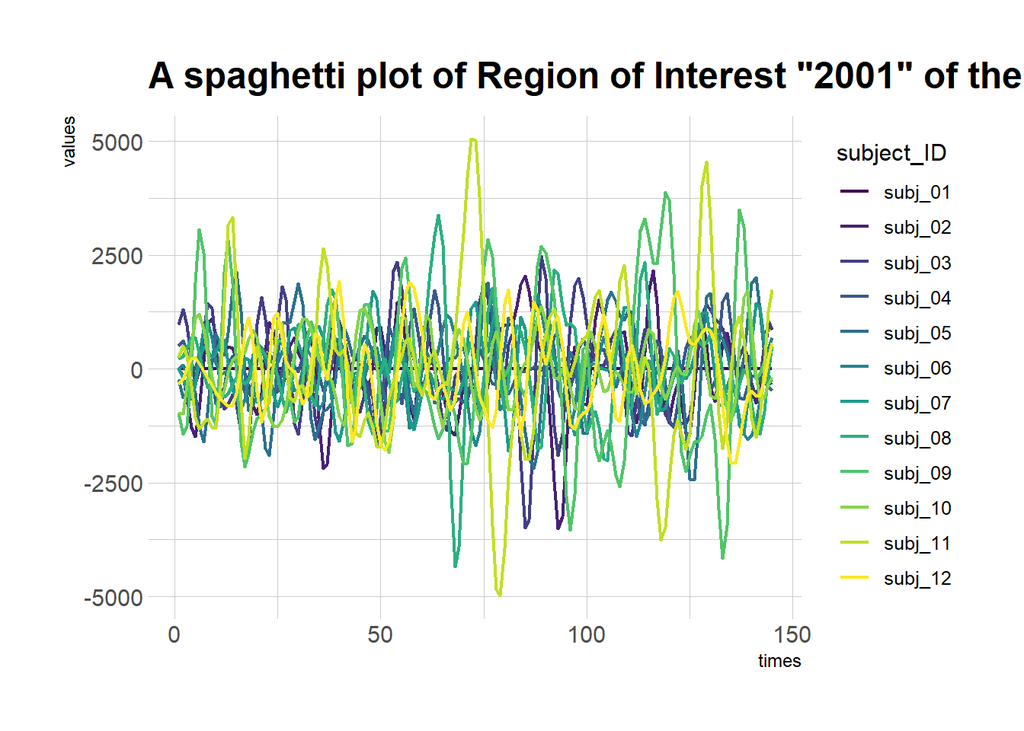

```r
#extract the ROI n°1 from all the subjects
get_roi <-function(dataframe, roi_id) {
  return(dataframe[, roi_id])
}

#dataframe that contains the only ROI NUMBER 1 of all the
#subject. 12 columns x 145 obs
roi1_all_subjects <- data.frame(sapply(asd_sel, get_roi, 1))

#add the times column, a numeric column of values from 1 to 145
roi1_all_subjects <- cbind(times = seq(1:145), roi1_all_subjects)

#pivoting the dataframe to make a plot
roi1_all_subjects_long <- roi1_all_subjects %>%
  pivot_longer(names(roi1_all_subjects)[-1], names_to = "subject_ID", values_to = "values")

#spaghetti plot of the ROI 2001 of 12 subjects
roi1_all_subjects_long %>%
  ggplot( aes(x=times, y=values, group=subject_ID, color=subject_ID)) +
  geom_line(size = 0.8) +
  scale_color_viridis(discrete = TRUE) +
  theme(
    legend.position="none",
    plot.title = element_text(size=14)
  ) +
  ggtitle("A spaghetti plot of Region of Interest \"2001\" of the 12 subjects ASD") +
  theme_ipsum()
```

Let’s see again the signal relative to the “2001” region only (since in the dataframe we have contrasted a similar behavior for the other regions), but now we highlight each of the 12 subjects in a reserved plot.

We note how the first subject (first plot at the top left) presents a null signal compared to the others.

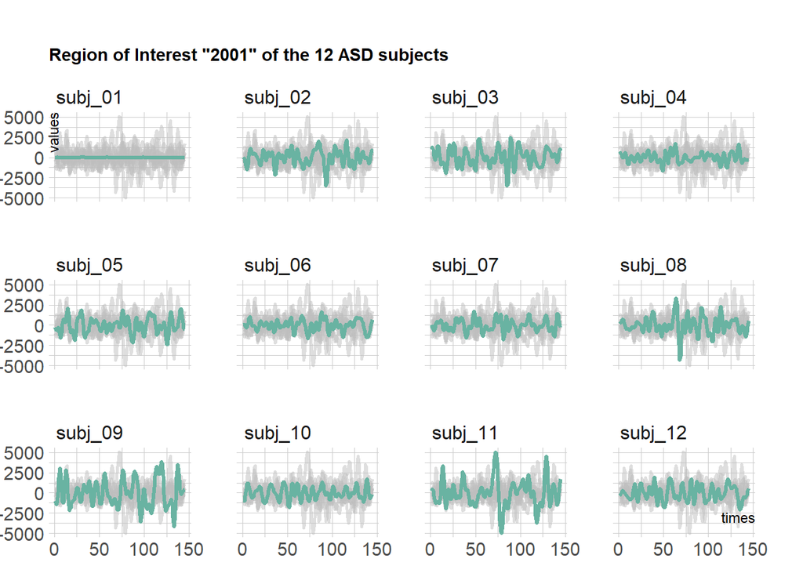

```r
#plot of the ROI "2001" of 12 subjects with individual subject highlighted
tmp <- roi1_all_subjects_long %>%
  mutate(name2=subject_ID)

tmp %>%
  ggplot( aes(x=times, y=values)) +
  geom_line( data=tmp %>% dplyr::select(-subject_ID), aes(group=name2), color="grey", size=1, alpha=0.5) +
  geom_line( aes(color=subject_ID), color="#69b3a2", size= 1.1)+
  scale_color_viridis(discrete = TRUE) +
  theme_ipsum() +
  theme(
    legend.position="none",
    plot.title = element_text(size=11),
    panel.grid = element_blank(),
      axis.title.x = element_text(margin = margin(t = -30)),
      axis.title.y = element_text(margin = margin(r = -40))
  ) +
  labs(title = "Region of Interest \"2001\" of the 12 ASD subjects") +
  facet_wrap(~subject_ID)
```

We conclude the *subject 01* is probabily an outlier.

### TD group

Also for the TD population we will see the range of the observations of the ROIs, showing again a sample of 8 regions per subject.

```r
#min e max value in all the ROI of all the TD subjects
range_all_subjects_TD <- lapply(td_sel, range_dataframe)
range_all_subjects_TD_df <- data.frame(range_all_subjects_TD)

#sample 8 regions per subject to print out, for tidiness
range_all_subjects_TD_df[sample(nrow(range_all_subjects_df),8, replace = F), ]
```

```
##      subj_01.min subj_01.max subj_02.min subj_02.max subj_03.min subj_03.max
## 2322   -1.533848    1.796620   -1.517772    1.107451   -2669.410    1963.618
## 2321   -1.626234    1.755050   -1.814745    2.123246   -3288.977    2719.985
## 2612   -2.837639    2.913734   -2.437502    1.791924  -12784.109   16784.330
## 6102   -3.061540    3.042540   -0.867513    0.844937   -5567.344    4622.467
## 4202   -2.015162    2.057748   -1.954403    2.173985   -5672.131    5023.347
## 9031   -1.757201    1.554341   -1.666018    2.744468   -2364.696    2537.175
## 9032   -1.721496    1.992204   -2.488689    3.477761   -3779.942    3603.266
## 9130   -1.861837    3.391326   -3.721766    3.846437   -5311.132    4598.521
##      subj_04.min subj_04.max subj_05.min subj_05.max subj_06.min subj_06.max
## 2322   -3035.867    2618.772   -2816.729    3147.595   -3455.484    2900.803
## 2321   -3536.552    3621.197   -4372.121    4818.059   -2832.431    3252.950
## 2612   -8868.283    7766.192   -7775.602   10609.604   -6256.491    8382.467
## 6102   -5959.046    6034.268   -5724.262    7799.668   -4949.883    4679.337
## 4202   -5729.169    8129.935   -6522.325    7558.855   -5333.215    7017.850
```

[output cut: 21 more lines]

We note as the *subject 01* and *subject 02* have a null signal.

We highlight this with a box plot, but this time we condense all the observations of all the ROIs relating to a subject. In other words, all the regions have been used and all the observations are consider in the plot.

In the boxplot we clearly see how the first two subjects can be considered outliers, beacause they do not show any observation significantly different from 0.

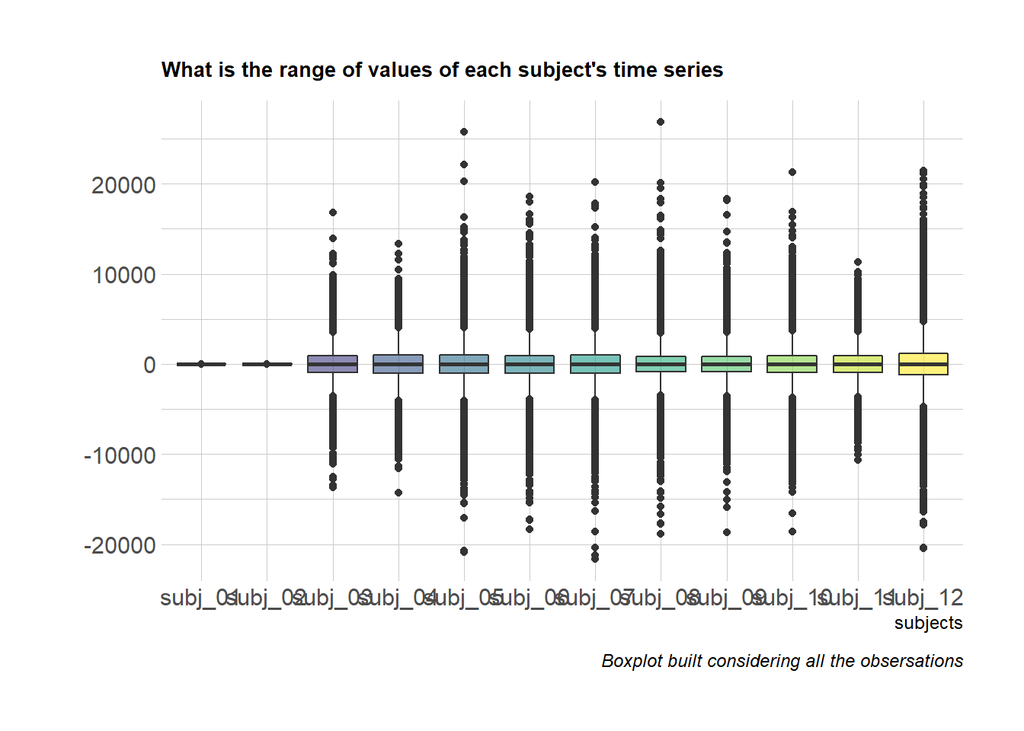

```r
#function that merge all the columns (ROI's) in a sigle column
flat_df <- function(data_frame, name) {
  return (data.frame(name = c(t(data_frame)), stringsAsFactors=FALSE))
}

#flat all the TD subjects
m <- mapply(flat_df, td_sel, names(td_sel))
all_ROI_per_subjects <- data.frame(m)

#rename the subjects for convenience
names(all_ROI_per_subjects) <- names(td_sel)

#pivot just for plot with ggplot
subjects_ROI <- all_ROI_per_subjects %>%
  pivot_longer(names(all_ROI_per_subjects), names_to = "subjects", values_to = "ROI_values")

#Boxplot

subjects_ROI %>%
  ggplot( aes(x=subjects, y=ROI_values, fill=subjects)) +
  geom_boxplot() +
  scale_fill_viridis(discrete = TRUE, alpha=0.6) +
  theme_ipsum() +
  theme(
    legend.position="none",
    plot.title = element_text(size=10)
  ) +
  labs(title = "What is the range of values of each subject's time series",
       caption = "Boxplot built considering all the obsersations") +
  xlab("subjects") +
  ylab("")
```

We so decided to discard the first subject of the ASD group, and the first and second subjects of the TD group.

From this point forward we no longer consider these subjects.

```r
#not consider outliers
asd <- asd_sel[-1]
td  <- td_sel[c(-1,-2)]
```

## Determination of the threshold

Let $\rho$ be the Pearson correlation. We set the threshold t equal to the 80th percentile of the correlation values observed in the two groups.

We start computing all the correlations of the ASD group, that is we compute 11 matrices (one per subject escluding the outlier), each of them is 116 x 116, where 116 is the number of the feautures (ROI). For each matrices, we then take one correlation per each pairs of ROI, taking only the elements below the diagonal, (since the correlation matrices are simmetric), we then concatenate all the correlation observed in the 11 subjects. In the end we make an histogram of the correlation observed.

[figure not shown]

```r
asd.cor <- lapply(asd, cor) # 11 matrices 116x116

#take only the elements below the diag and concat the data
corr.obs.asd <- c(sapply(asd.cor, function(x) x[lower.tri(x)], simplify = T))

hist(corr.obs.asd, probability = T, col = "orange", border = "white",
     main = "Histogram of correlation observed in the TD Group",
     xlab = expression(rho[ASD]))
```

```r
round(summary(corr.obs.asd),3)
```

```
##    Min. 1st Qu.  Median    Mean 3rd Qu.    Max.
##  -0.873  -0.182  -0.016  -0.001   0.164   0.949
```

Now for the TD group as above:

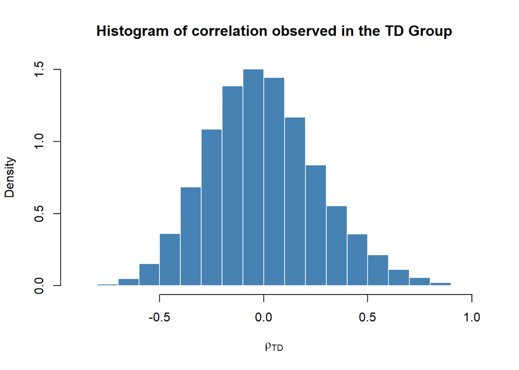

```r
td.cor <- lapply(td, cor) # 10 matrices 116x116
corr.obs.td <- c(sapply(td.cor, function(x) x[lower.tri(x)], simplify = T))

hist(corr.obs.td, probability = T, col = "steelblue", border = "white",
     main = "Histogram of correlation observed in the TD Group",
     xlab = expression(rho[TD]))
```

```r
round(summary(corr.obs.td),3)
```

```
##    Min. 1st Qu.  Median    Mean 3rd Qu.    Max.
##  -0.824  -0.188  -0.016  -0.002   0.167   0.938
```

We now concatenate the observed correlations of the two groups together and we pick as threshold the 80th percentile:

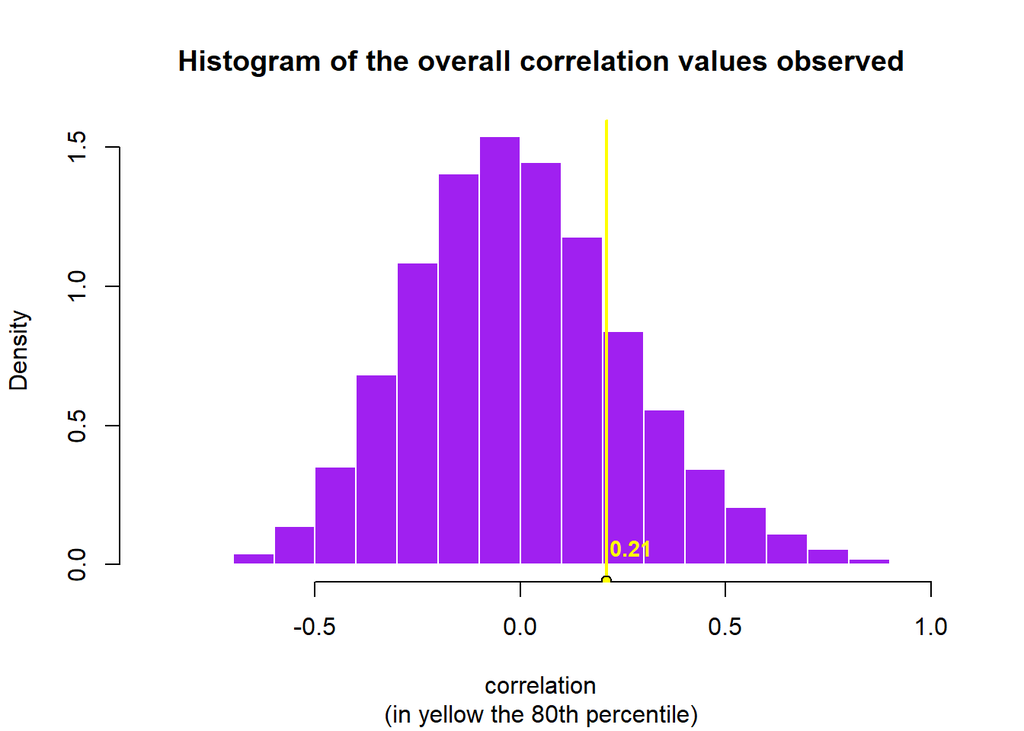

```r
#union of the data
corr.obs <- c(corr.obs.asd, corr.obs.td)

hist(corr.obs, probability = T, col = "purple", border = "white",
     xlab = "correlation",
     main = "Histogram of the overall correlation values observed",
     sub = "(in yellow the 80th percentile)")

th <- quantile(corr.obs, probs = 0.80)
th <- round(th, 2)
abline(v = th, lwd = 2, col = "yellow")
points(x = th, y = - 0.06, pch = 21, col = "black", bg = "yellow")
text(x = th + 0.06,y = 0.06, labels = "0.21", col = "yellow", cex = 0.9,
     font = 2)
```

```r
cat("Threshold fixed at:", round(th,3))
```

```
## Threshold fixed at: 0.21
```

We note how the distribution of the Pearson corellation is skewed, a fact that will return later.

## Pooling together the data: The Mean

Since we want obtain a sigle graph to the ASD $G_{ASD}$, and a graph to the TD group $G_{TD}$, we need to pool together the data of subjects belowing to the same group.

Our choice was the sample mean. The motivation are: it is widely used in statistics as summaries of a population and it is easy to compute.

As known, the main disadvantage is that it does not work well in the presence of outliers, but we have removed them previously.

In the original dataset, each subject has 116 regions x 145 observations (145 time instants for each region). As result of this “pooling procedure” will be a single subject, also characterized by 116 regions x 145 observations.

So, in making the average between the subjects we are careful in averaging between corresponding instants of time (i.e. the average of the first instant of the first region of the subjects will be the first instant of the first region of the result, the second instant of the first region of the subjects will be the second instant of the first region of the result, etc …)

```r
for (i in 1 : length(asd)) {
  asd[[i]] <- cbind(index = seq(1, 145), asd[[i]])
}

# build a dataframe containg the average of the original cells,
# combining the cells with the same index and same roi
asd_mean <- rbindlist(asd)[,lapply(.SD,mean), index]

#remove the index column
asd_mean <- subset(asd_mean, select = -c(index))

#rename the subjects TD
names(td_sel) <- c(paste("subj", seq(1,9), sep = '_0'),
                    paste("subj", seq(10,12), sep = '_'))

#not consider the two outliers
td <- td_sel[c(-1,-2)]

#add a column called index, with number from 1 to 145
for (i in 1 : length(td)) {
  td[[i]] <- cbind(index = seq(1, 145), td[[i]])
}

# build a dataframe containg the average of the original cells,
# combining the cells with the same index and same roi
td_mean <- rbindlist(td)[,lapply(.SD,mean), index]

#remove the index column
td_mean <- subset(td_mean, select = -c(index))
```

Dimension of the dataframe resulting for the ASD:

```r
dim(asd_mean)
```

```
## [1] 145 116
```

First 5 columns and 5 rows of the result, for the ASD.

```r
asd_mean[1:5, 1:5]
```

```
##          2001       2002         2101       2102     2111
## 1:  -48.06852  339.73713   0.09821978 -318.60730 229.2245
## 2:  -77.36222  293.91486  67.36656536 -387.03473 227.6481
## 3: -122.60038  -83.19557 112.10541534 -266.38917 110.7500
## 4: -121.57427 -492.67165 108.21905760  -54.62659 131.7763
## 5:  -10.61562 -557.20808  36.42543788   75.43950 302.8047
```

Dimension of the dataframe resulting for the TD:

```r
dim(td_mean)
```

```
## [1] 145 116
```

First 5 columns and 5 rows of the result, for the TD.

```r
td_mean[1:5, 1:5]
```

```
##         2001      2002      2101       2102       2111
## 1: -53.32947 -551.4467 186.55480  389.24825 -361.45085
## 2: 101.30651 -276.0173  65.43410  504.80439 -559.78756
## 3: 226.88703  272.8125 -49.32191  321.96931 -454.90259
## 4: 274.20606  645.5337 -27.00160  -12.63456   18.62172
## 5: 278.00621  548.1849  92.18925 -263.76525  603.46325
```

## Confidence Interval and Bonferroni Correction

In order to test is $|\rho| > t$ we build a confidence interval $C_{j,k}(\alpha)$ for $(j, k)$, and then we place an edge between feature j and feature k if $[−t,+t] \cap C_{j,k}(\alpha) = \emptyset$.

We first build a confidence set without controlling for multiplicity, and so we fix the significance level $\alpha$ to 0.05.

Since will test multiple hypothesis, the chance of observing a rare event increases, and therefore, the likelihood of incorrectly rejecting a null hypothesis, increases.

The Bonferroni correction compensates for that increase by testing each individual hypothesis at a significance level of $\frac{\alpha}{m}$, where $\alpha$ is the desired overall type I error probability and m is the number of hypothesis, that is $m =$ ${116}\choose{2}$ $= 6670$.

Hence, we build a confidence sets at level $1 - \frac{\alpha}{m}$, where $\alpha$ is 0.05.

### Confidence Interval: Fisher Z Transform

We said we want to test the statistical significance of Pearson correlation cofficent $\rho$. However the variance of $\rho$ is complex. Techniques have been developed to estimate the variance, applied specific trasformation, such that, when transformed back into original units, the coverage of CIs constructed in this manner will approximate the nominal level. One of the them is the Fisher trasform. After Fisher-transforming $\rho$, where
$$z = atanh(\rho)$$
the estimate of the variance of $z$ is
$$\sigma^2 = \frac{1}{(N – 3)}$$

With this estimate of the sampling error of z, and the assumption that these errors are normally distributed, one can construct a CI as follows:

$$CI = tanh[z - \sigma \times z_{\frac{\alpha}{2}}, z + \sigma \times z_{(1 - \frac{\alpha}{2})} ]$$
where $z_{\frac{\alpha}{2}}$ is the percentile point of a standard normal distribution below which the subscripted proportion of scores lies. And in the case of *unilateral confidence interval* we said
$$CI = tanh[z - \sigma \times z_{\alpha}, +\infty ]$$

Since our goal is to test if $|\rho| > t$, we build a *unilateral confidence interval*.

*Null hypothesis:* $|\rho| < t$ *Alternative hypothesis:* $|\rho| \geq t$

with $t > 0$.

In order to do that, we look at the function of R *cor.test* ,that compute a test of the value being zero, and we have adapted it to test a value strictly greater than 0.

```r
my.cor.test <- function(x,y, r0, conf.level = 0.95) {
  #r0 is the correlation according to null hypothesis
  n <- length(x)
  r <- cor(x, y)

  r <- abs(r) #test is |r| > r0
  z.r <- atanh(r)
  z.r0 <- atanh(r0)
  sigma <- 1 / sqrt(n - 3)
  z <- (z.r - z.r0)/sigma

  cint <- c(z.r - sigma * qnorm(conf.level), Inf) #single sided CI
  cint <- tanh(cint)
  pval <- pnorm(z, lower.tail=FALSE)

  list(conf.int = cint, p.value = pval)
}
```

The function *my.cor.mtest* make a significance test which produces p-values and confidence intervals for each pair of input features, calling our function *my.cor.test*. Also here too we have based on the code of R *cor.mtest*.

```r
my.cor.mtest <- function(mat, r0, conf.level = 0.95)
{
  mat <- as.matrix(mat)
  n <- ncol(mat)
  p.mat <- lowCI.mat <- uppCI.mat <- matrix(NA, n, n)
  diag(p.mat) <- 1
  diag(lowCI.mat) <- diag(uppCI.mat) <- 0
  for (i in 1:(n - 1)) {
    for (j in (i + 1):n) {
      tmp <- my.cor.test(x = mat[, i], y = mat[, j], r0 = r0, conf.level = conf.level)
      p.mat[i, j] <- p.mat[j, i] <- tmp$p.value
      if (!is.null(tmp$conf.int)) {
        lowCI.mat[i, j] <- lowCI.mat[j, i] <- tmp$conf.int[1]
        uppCI.mat[i, j] <- uppCI.mat[j, i] <- tmp$conf.int[2]
      }
    }
  }
  list(p = p.mat, lowCI = lowCI.mat, uppCI = uppCI.mat)
}
```

We first determinate the two population graphs, without controlling for multiplicity, setting the confidence level at 0.95.

The result:

```r
#116x116 corelation matrix
cor.mat <- cor(td_mean)
cor.asd.matrix <- cor(asd_mean)

alpha <- 0.05
n <- ncol(asd_mean)
m <- choose(n, 2) # binomial coefficients: number of pairs
th <- 0.21 #threshold

asd_multi_matrix <- my.cor.mtest(asd_mean, r0 = th, conf.level = 0.95)

cat("ASD group \n")
```

```
## ASD group
```

```r
cat("Number of edges setting p-value < alpha \n")
```

```
## Number of edges setting p-value < alpha
```

```r
asd_edges_index <- which(asd_multi_matrix$p < alpha)
length(asd_edges_index)/2
```

```
## [1] 834
```

```r
cat("\n")
```

```r
cat("some indeces according to the test on the pvalue: \n")
```

```
## some indeces according to the test on the pvalue:
```

```r
head(asd_edges_index, n = 50)
```

```
##  [1]   2  11  19  26  32  46  57  68 117 136 142 148 161 162 167 173 174 178 180
## [20] 184 185 236 237 239 240 241 245 255 256 263 270 297 311 328 329 330 331 332
## [39] 336 342 343 344 346 351 353 354 355 356 358 371
```

```r
cat('\n')
```

```r
cat("Number of edges cheching which confidence intervals does not intersect [-t, +t] \n")
```

```
## Number of edges cheching which confidence intervals does not intersect [-t, +t]
```

```r
asd_index <- which(th < asd_multi_matrix$lowCI)
length(asd_index)/2
```

```
## [1] 834
```

```r
cat('\n')
```

```r
cat("some indeces according to the test on the confidence interval\n")
```

```
## some indeces according to the test on the confidence interval
```

```r
head(asd_index, n = 50)
```

```
##  [1]   2  11  19  26  32  46  57  68 117 136 142 148 161 162 167 173 174 178 180
## [20] 184 185 236 237 239 240 241 245 255 256 263 270 297 311 328 329 330 331 332
## [39] 336 342 343 344 346 351 353 354 355 356 358 371
```

As expected, there are perfect equivalence between verifying the value of the *pvalue* and the confidence interval.

```r
# TD SUBJECTS
td_multi_matrix <- my.cor.mtest(td_mean, r0 = th, conf.level = 0.95)
td_edges_index <- which(td_multi_matrix$p < alpha)
cat('\n')
```

```r
cat("TD group \n")
```

```
## TD group
```

```r
cat("Number of edges setting p-value < alpha : \n")
```

```
## Number of edges setting p-value < alpha :
```

```r
length(td_edges_index)/2
```

```
## [1] 924
```

```r
cat("some indeces according to the test on the pvalue:\n")
```

```
## some indeces according to the test on the pvalue:
```

```r
head(td_edges_index, n = 50)
```

```
##  [1]  11  17  18  26  35  36  43  57  61  63  64  68  75 133 145 154 169 171 178
## [20] 180 184 236 237 239 240 241 242 250 255 262 270 272 297 312 313 314 321 328
## [39] 332 351 354 356 366 371 374 376 377 378 383 412
```

```r
cat('\n')
```

```r
cat("Number of edges cheching which confidence intervals does not intersect [-t -t]: \n")
```

```
## Number of edges cheching which confidence intervals does not intersect [-t -t]:
```

```r
td_index <- which(th < td_multi_matrix$lowCI)
length(td_index)/2
```

```
## [1] 924
```

```r
cat("\n")
```

```r
cat("some indeces according to the confidence intervals:")
```

```
## some indeces according to the confidence intervals:
```

```r
head(td_index, n = 50)
```

```
##  [1]  11  17  18  26  35  36  43  57  61  63  64  68  75 133 145 154 169 171 178
## [20] 180 184 236 237 239 240 241 242 250 255 262 270 272 297 312 313 314 321 328
## [39] 332 351 354 356 366 371 374 376 377 378 383 412
```

We proceed now with the *Bonferroni control*: setting as condition of significance:

- level of confidence of the intervals: $1 - \frac{\alpha}{m}$ or equivalently
- $p_{value} < \frac{\alpha}{m}$

```r
t_bonf <- alpha/m
bon_asd_edges_index <- which(asd_multi_matrix$p < alpha/m)  # the p value not depens on conf.level

cat("ASD subject: \n")
```

```
## ASD subject:
```

```r
cat("Number of edges testing p-value (bonferroni correction): \n")
```

```
## Number of edges testing p-value (bonferroni correction):
```

```r
length(bon_asd_edges_index)/2
```

```
## [1] 145
```

```r
cat('\n')
```

```r
bon_asd_multi_matrix <- my.cor.mtest(asd_mean, r0 = th, conf.level = 1 - (alpha/m))

cat("Number of edges testing the confidence interval (bonferroni correction: \n")
```

```
## Number of edges testing the confidence interval (bonferroni correction:
```

```r
bon_asd_index <- which(th < bon_asd_multi_matrix$lowCI)
length(bon_asd_index)/2
```

```
## [1] 145
```

```r
cat("\n")
```

```r
cat("TD Subject: \n")
```

```
## TD Subject:
```

```r
cat("Number of edges testing p-value (bonferroni correction) : \n")
```

```
## Number of edges testing p-value (bonferroni correction) :
```

```r
bon_td_edges_index <- which(td_multi_matrix$p < alpha/m)
length(bon_td_edges_index) /2
```

```
## [1] 195
```

```r
cat("\n")
```

```r
bon_td_multi_matrix <- my.cor.mtest(td_mean, r0 = th, conf.level = 1 - (alpha/m))

cat("Number of edges testing the confidence interval (bonferroni correction:\n")
```

```
## Number of edges testing the confidence interval (bonferroni correction:
```

```r
bon_td_index <- which(th < bon_td_multi_matrix$lowCI)
length(bon_td_index)/2
```

```
## [1] 195
```

We proceed now building the confidence intervals of the difference between the correlations relatives to same ROIs of different group.

For testing the difference between to correlation $\rho1$ and $\rho2$ we proceed as follow:

- transform the correlations using the Fisher-z transformation, $z1 = atanh(\rho1)$ and $z2 = atanh(\rho2)$
- The standard deviation of the difference is given by
  $$\sigma = \sqrt{2 \frac{1}{N - 3} }$$
- Build the CI at prefixed level as before.

Below the definition of the functions used:

```r
my.cor.dif.test <- function(x1, y1, x2, y2, r0, conf.level = 0.95) {
  #r0 is the correlation according to null hypothesis
  #x1 : value x of group 1   #y1 : value y of group 1
  #x2 : value x of group 2   #y2 : value y of group 2

  n1 <- length(x1)
  n2 <- length(x2)
  r1 <- cor(x1, y1)
  r2 <- cor(x2, y2)

  if (r2 > r1) {
    tp <- r1
    r1 <- r2
    r2 <- tp
  }

  z1 <- atanh(r1)
  z2 <- atanh(r2)
  var1 <- (1 / (n1 - 3))
  var2 <- (1 / (n2 - 3))
  sigma <- sqrt(var1 + var2) # standard error of the statistic

  z.r  <- (z1 - z2)
  z.r0 <- atanh(r0)
  z <- (z.r - z.r0)/sigma

  cint <- c(z.r - sigma * qnorm(conf.level), Inf)
  cint <- tanh(cint)
  pval <- pnorm(z, lower.tail=FALSE)

  list(conf.int = cint, p.value = pval)
}
```

```r
my.dif.cor.mtest <- function(mat_g1, mat_g2, r0, conf.level = 0.95)
{
  mat_g1 <- as.matrix(mat_g1)
  mat_g2 <- as.matrix(mat_g2)
  n <- ncol(mat_g1)
  p.mat <- lowCI.mat <- uppCI.mat <- matrix(NA, n, n)
  diag(p.mat) <- 1
  diag(lowCI.mat) <- diag(uppCI.mat) <- 0
  for (i in 1:(n - 1)) {
    for (j in (i + 1):n) {
      tmp <- my.cor.dif.test(x1 = mat_g1[, i], y1 = mat_g1[, j],
                             x2 = mat_g2[, i], y2 = mat_g2[, j],
                             r0 = r0, conf.level = conf.level)
      p.mat[i, j] <- p.mat[j, i] <- tmp$p.value
      if (!is.null(tmp$conf.int)) {
        lowCI.mat[i, j] <- lowCI.mat[j, i] <- tmp$conf.int[1]
        uppCI.mat[i, j] <- uppCI.mat[j, i] <- tmp$conf.int[2]
      }
    }
  }
  list(p = p.mat, lowCI = lowCI.mat, uppCI = uppCI.mat)
}
```

The Results. Below we see the number of edges in the graph of the difference between the association graph of the two population without the Bonferroni control:

```r
asd.cor.mat <- cor(asd_mean)
td.cor.mat <- cor(td_mean)
delta.corr.mat <- abs(asd.cor.mat - td.cor.mat)

# Difference between Correlation: without control -------------

dif_multi <- my.dif.cor.mtest(asd_mean, td_mean, r0 = th)
dif.pmat <- dif_multi$p

cat("Result of the difference between correlations without control: \n\n")
```

```
## Result of the difference between correlations without control:
```

```r
cat("Number of edges in the graph of the difference according to pvalue: \n")
```

```
## Number of edges in the graph of the difference according to pvalue:
```

```r
(sum(dif_multi$p < alpha))/2
```

```
## [1] 339
```

```r
cat("\n")
```

```r
cat("Number of edges in the graph of the difference according to the CI \n")
```

```
## Number of edges in the graph of the difference according to the CI
```

```r
(sum(dif_multi$lowCI > th))/2
```

```
## [1] 339
```

We show below only 20 of the 339 significative edges, with the relative correlation values, and confidence intervals:

```r
# which edges are linked
dif.low <- dif_multi$lowCI
dimnames(dif.low) <- dimnames(asd.cor.mat)
dif.low[lower.tri(dif.low, diag = T)] <- 0
idx.nc <- which(dif.low > th, arr.ind=TRUE)
edges.nc <- cbind(rownames(dif.low)[idx.nc[,"row"]], colnames(dif.low)[idx.nc[,"col"]])
edges.nc.labels <- apply(X = edges.nc, MARGIN = 1, function(x) paste(x[1], x[2], sep = "-"))

results.no.control <- data.frame(
  edges = edges.nc.labels,
  corr_ASD = round(asd.cor.mat[idx.nc],3),
  corr_TD = round(td.cor.mat[idx.nc],3),
  delta_corr = round(delta.corr.mat[idx.nc],3),
  delta_CI95_low = round(dif.low[idx.nc],3)
)

head(results.no.control, n = 20)
```

```
##        edges corr_ASD corr_TD delta_corr delta_CI95_low
## 1  2102-2111    0.340  -0.137      0.477          0.288
## 2  2101-2201    0.793   0.482      0.311          0.344
## 3  2111-2202    0.548   0.022      0.526          0.378
## 4  2102-2211    0.305  -0.183      0.489          0.296
## 5  2202-2211    0.525   0.109      0.416          0.271
## 6  2102-2212    0.577  -0.074      0.651          0.490
## 7  2112-2212    0.576   0.141      0.436          0.310
## 8  2201-2301    0.253   0.600      0.347          0.235
## 9  2212-2301   -0.215   0.343      0.558          0.363
## 10 2001-2331    0.117   0.528      0.411          0.268
## 11 2111-2331   -0.255   0.243      0.498          0.303
## 12 2301-2331    0.601   0.272      0.329          0.216
## 13 2002-2401    0.297  -0.146      0.443          0.253
## 14 2311-2402    0.113  -0.357      0.470          0.283
## 15 2101-2501   -0.233   0.213      0.446          0.253
## 16 2111-2501   -0.269   0.211      0.480          0.286
## 17 2311-2501   -0.365   0.119      0.484          0.297
## 18 2101-2502   -0.261   0.142      0.402          0.211
## 19 2311-2502   -0.306   0.131      0.437          0.247
## 20 2502-2601   -0.105   0.302      0.407          0.218
```

Also for the association graph of the difference, we proceed with the *Bonferroni Adjustment,* building the CI at level $1 - \frac{\alpha}{m}$:

```r
# Difference between correlation: Bonferoni Control -----------------------

th <- 0.21
t_bonf <- (alpha/m)  #bonferroni threshold

dif_bon_multi <- my.dif.cor.mtest(asd_mean, td_mean, r0 = th, conf.level = 1 - (alpha/m))

dif.bon.pmat <- dif_bon_multi$p #pvalues matrix
D.bon.lowCI <- dif_bon_multi$lowCI #lower extreme of the Confidence Intervals
dimnames(D.bon.lowCI) <- dimnames(cor.mat)


#which ROI are linked
verteces.liked.p <- which(dif_bon_multi$p < t_bonf)
verteces.liked   <- which(dif_bon_multi$lowCI > th)


# which edges are linked
cat("how many edges there are in the graph Delta\n")
```

```
## how many edges there are in the graph Delta
```

```r
cat("with Bonferroni correction:\n")
```

```
## with Bonferroni correction:
```

```r
length(verteces.liked)/2
```

```
## [1] 4
```

```r
dif.bon.low <- dif_bon_multi$lowCI
dif.bon.low[lower.tri(dif.bon.low, diag = T)] <- 0
idx <- which(dif.bon.low > th, arr.ind=TRUE)
edges.bon <- cbind(rownames(D.bon.lowCI)[idx[,"row"]], colnames(D.bon.lowCI)[idx[,"col"]])

verteces.liked.name <- union(rownames(D.bon.lowCI)[idx[,"row"]], colnames(D.bon.lowCI)[idx[,"col"]])
edges.bon.labels <- apply(X = edges.bon, MARGIN = 1, function(x) paste(x[1], x[2], sep = "-"))

#correlation matrices
#difference corr matrix
asd.cor.mat <- cor(asd_mean)
td.cor.mat <- cor(td_mean)
delta.corr.mat <- abs(asd.cor.mat - td.cor.mat)
asd.result <- round(asd.cor.mat[idx],3)
td.result <- round(td.cor.mat[idx],3)

results.bonf <- data.frame(
  ROI_IDs = edges.bon.labels,
  corr_ASD = round(asd.cor.mat[idx],3),
  corr_TD = round(td.cor.mat[idx],3),
  delta_corr = round(delta.corr.mat[idx],3),
  delta_CI_low = round(dif.bon.low[idx],3)
)
```

After adjusting with Bonferroni, only 4 edges are significant. Infact, the Bonferroni correction it may be too conservative (leading too few discoveries). Below the details of the 4 edges:

```r
results.bonf
```

```
##     ROI_IDs corr_ASD corr_TD delta_corr delta_CI_low
## 1 2102-2212    0.577  -0.074      0.651        0.214
## 2 2102-4021   -0.297   0.405      0.702        0.219
## 3 8211-8212    0.761   0.251      0.510        0.225
## 4 8212-9031   -0.249   0.441      0.690        0.210
```

#### Scatterplots of the significant egdes found

We are interested in seeing the scatter plots related to the 4 nodes found in the two original groups.

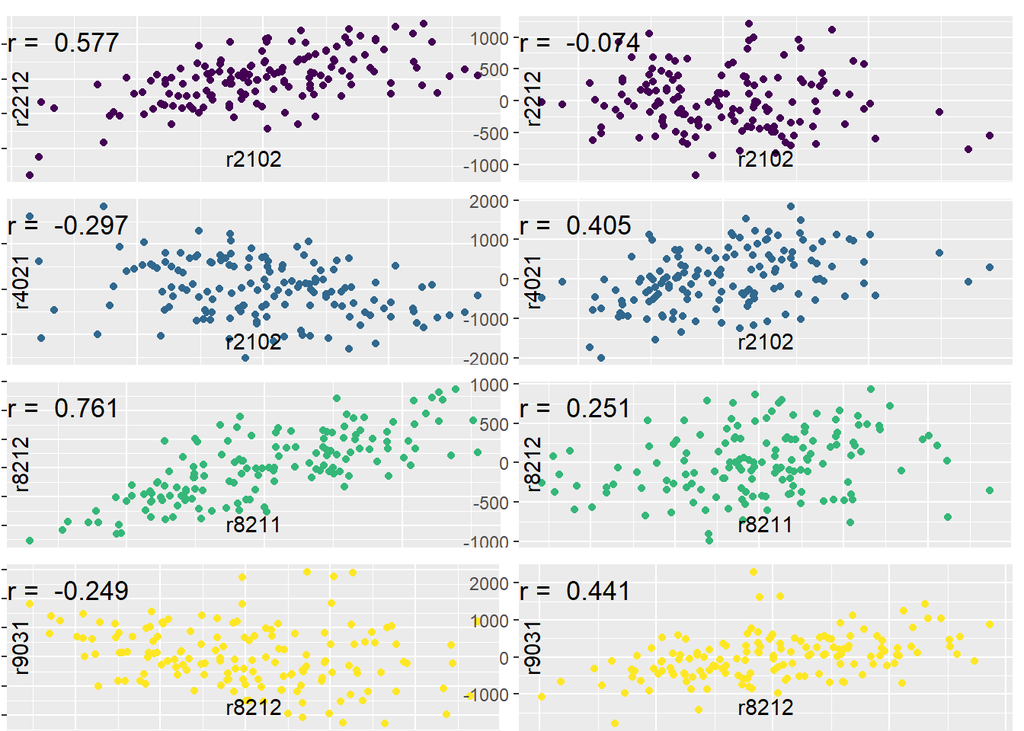

```r
# Correlation p: Scatterplots ---------------------------------------------


# basic scatterplot
require("gridExtra")
require("cowplot")

data <- asd_mean%>% select(verteces.liked.name)
names(data) <- paste(c("r"),names(data), sep="")
data_td <- td_mean%>% select(verteces.liked.name)
names(data_td) <- paste(c("r"),names(data_td), sep="")
colrs <- viridis(nrow(edges.bon))

new.edges <- matrix(NA, nrow = nrow(edges.bon), ncol = ncol(edges.bon))
for (i in 1 : nrow(edges.bon)) {
  new.edges[i,1] <- paste("r", edges.bon[i,1], sep = "")
  new.edges[i,2] <- paste("r", edges.bon[i,2], sep = "")
}

a <- ggplot(data, aes(x=r2102, y=r2212)) +
  geom_point(color = colrs[1]) +
  ggtitle(paste("r = ", asd.result[1])) +
  theme(plot.title = element_text(margin = margin(t = 10, b = -20)),
        axis.title.x = element_text(margin = margin(t = -30)),
        axis.title.y = element_text(margin = margin(r = -40))
        )

b <- ggplot(data, aes(x=r2102, y=r4021)) +
  geom_point(color = colrs[2]) +
  ggtitle(paste("r = ", asd.result[2])) +
  theme(plot.title = element_text(margin = margin(t = 10, b = -20)),
        axis.title.x = element_text(margin = margin(t = -30)),
        axis.title.y = element_text(margin = margin(r = -40))
  )

c <- ggplot(data, aes(x=r8211, y=r8212)) +
  geom_point(color = colrs[3]) +
  ggtitle(paste("r = ", asd.result[3])) +
  theme(plot.title = element_text(margin = margin(t = 10, b = -20)),
        axis.title.x = element_text(margin = margin(t = -30)),
        axis.title.y = element_text(margin = margin(r = -40))
  )
d <- ggplot(data, aes(x=r8212, y=r9031)) +
  geom_point(color = colrs[4]) +
  ggtitle(paste("r = ", asd.result[4])) +
  theme(plot.title = element_text(margin = margin(t = 10, b = -20)),
        axis.title.x = element_text(margin = margin(t = -30)),
        axis.title.y = element_text(margin = margin(r = -40))
  )

a2 <- ggplot(data_td, aes(x=r2102, y=r2212)) +
  geom_point(color = colrs[1]) +
  ggtitle(paste("r = ", td.result[1])) +
  theme(plot.title = element_text(margin = margin(t = 10, b = -20)),
        axis.title.x = element_text(margin = margin(t = -30)),
        axis.title.y = element_text(margin = margin(r = -40))
  )
b2 <- ggplot(data_td, aes(x=r2102, y=r4021)) +
  geom_point(color = colrs[2]) +
  ggtitle(paste("r = ", td.result[2])) +
  theme(plot.title = element_text(margin = margin(t = 10, b = -20)),
        axis.title.x = element_text(margin = margin(t = -30)),
        axis.title.y = element_text(margin = margin(r = -40))
  )
c2 <- ggplot(data_td, aes(x=r8211, y=r8212)) +
  geom_point(color = colrs[3]) +
  ggtitle(paste("r = ", td.result[3])) +
  theme(plot.title = element_text(margin = margin(t = 10, b = -20)),
        axis.title.x = element_text(margin = margin(t = -30)),
        axis.title.y = element_text(margin = margin(r = -40))
  )
d2 <- ggplot(data_td, aes(x=r8212, y=r9031)) +
  geom_point(color = colrs[4]) +
  ggtitle(paste("r = ", td.result[4])) +
  theme(plot.title = element_text(margin = margin(t = 10, b = -20)),
        axis.title.x = element_text(margin = margin(t = -30)),
        axis.title.y = element_text(margin = margin(r = -40))
  )
plot_grid(a,a2,b,b2,c,c2,d,d2, ncol = 2, nrow = 4)
```

### Graphs

We look now at the results through graphs.

We build a graph relatives to the ASD subject, a graph relatives to the TD subject, and the graph based on the difference between the correlations $G^{\Delta}(t)$, with Bonferroni correction in all of them. <>

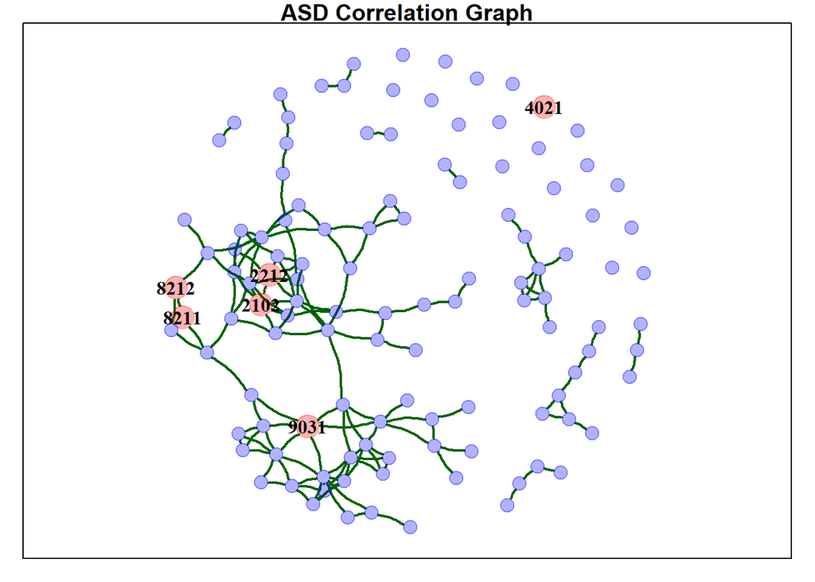

```r
asd_bon_pmat <- bon_asd_multi_matrix$p
asd_bon_adj_mat <- matrix(0, nrow = n, ncol = n, dimnames = dimnames(cor.asd.matrix))
asd_bon_adj_mat[ which(asd_bon_pmat < t_bonf) ] <- 1

G_asd_bon <-graph_from_adjacency_matrix(asd_bon_adj_mat, mode = "undirected")

# TD SUBJECTS

td_bon_pmat <- bon_td_multi_matrix$p
td_bon_adj_mat <- matrix(0, nrow = n, ncol = n, dimnames = dimnames(cor.asd.matrix))
td_bon_adj_mat[ which(td_bon_pmat < t_bonf) ] <- 1

G_td_bon <-graph_from_adjacency_matrix(td_bon_adj_mat, mode = "undirected")
dif_bon_pmat <- dif_bon_multi$p
dif_bon_adj_mat <- matrix(0, nrow = n, ncol = n, dimnames = dimnames(cor.asd.matrix))
dif_bon_adj_mat [which(dif_bon_pmat < t_bonf)] <- 1

G_delta_bon <-graph_from_adjacency_matrix(dif_bon_adj_mat, mode = "undirected")

mask <- which(V(G_td_bon)$name %in% verteces.liked.name)
vertx.size <- rep(8, 116)
vertx.size[mask] <- 16

vertx.col <- rep(rgb(0,0,1,.3), 116)
vertx.col[mask] <- c(rgb(1,0,0,.3))

mask <- which(V(G_td_bon)$name %in% verteces.liked.name)
vertx.size <- rep(6, 116)
vertx.size[mask] <- 10

labels <- V(G_asd_bon)$name
vertx.label <- rep(NA, 116)
vertx.label[mask] <- labels[mask]

vertx.col <- rep(rgb(0,0,1,.3), 116)
vertx.col[mask] <- c(rgb(1,0,0,.3))

par(mfrow=c(1,1),  mar=c(1,1,1,1), family = "sans", font.sub = 2, cex.sub = 0.8)

plot(G_asd_bon,
     vertex.size = vertx.size,
     vertex.shape = "circle",
     vertex.label = vertx.label,
     vertex.label.cex = 1,
     vertex.label.font = 2,
     vertex.label.color="black",
     vertex.color = vertx.col,
     edge.curved=0.2,
     edge.width = 2,
     edge.color = "darkgreen",
     curved = TRUE,
     main = "ASD Correlation Graph",
     sub = "Bonferroni adjustment",
     frame = T,
     vertex.frame.color = vertx.col
)
```

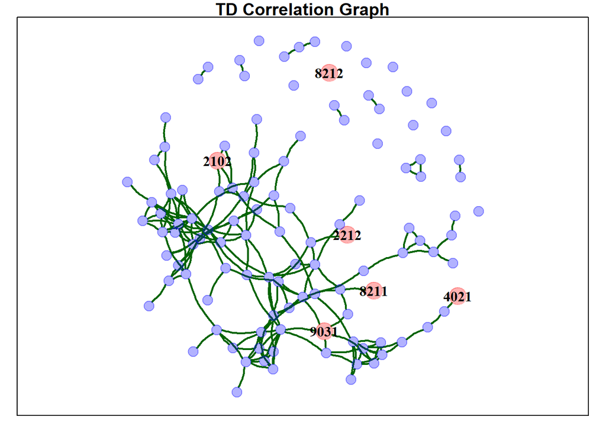

```r
plot(G_td_bon,
     vertex.size = vertx.size,
     vertex.shape = "circle",
     vertex.label = vertx.label,
     vertex.label.cex = 1,
     vertex.label.font = 2,
     vertex.label.color="black",
     vertex.color = vertx.col,
     edge.curved=0.2,
     edge.width = 2,
     edge.color = "darkgreen",
     curved = TRUE,
     main = "TD Correlation Graph",
     sub = "Bonferroni adjustment",
     frame = T,
     vertex.frame.color = vertx.col
)
```

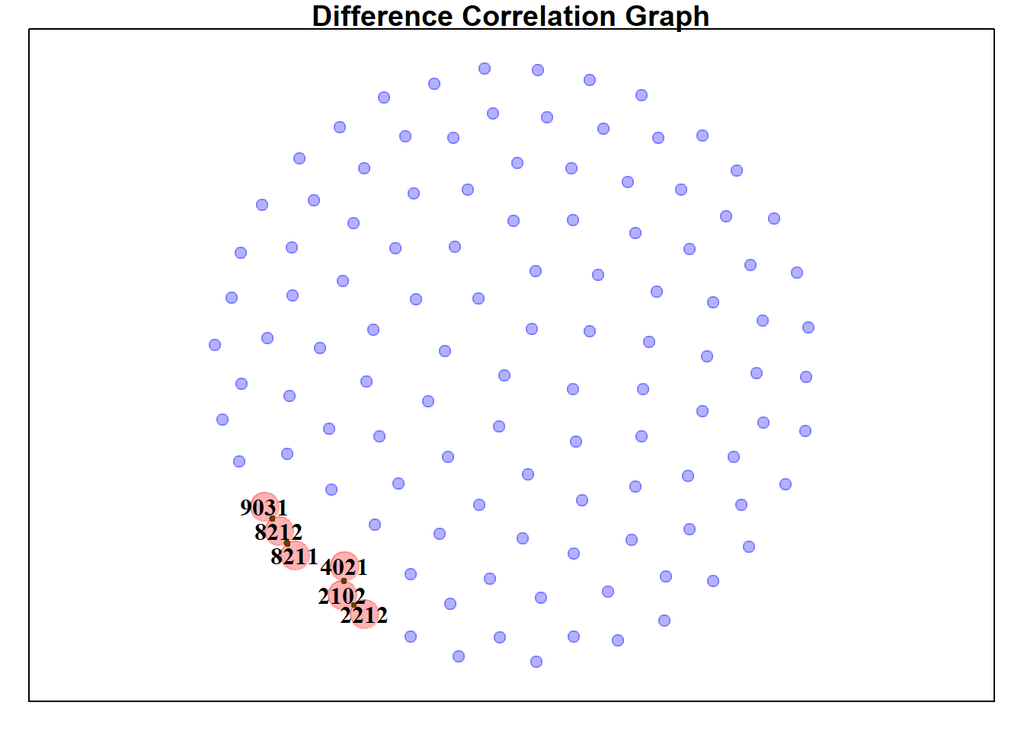

```r
vertx.size <- rep(4, 116)
vertx.size[mask] <- 10

plot(G_delta_bon,
     vertex.size = vertx.size,
     vertex.shape = "circle",
     vertex.label = vertx.label,
     vertex.label.cex = 1,
     vertex.label.font = 2,
     vertex.label.color="black",
     vertex.color = vertx.col,
     edge.curved=0.2,
     edge.width = 4,
     edge.color = "darkgreen",
     curved = TRUE,
     main = "Difference Correlation Graph",
     sub = "Bonferroni adjustment",
     frame = T,
     vertex.frame.color = vertx.col
)
```

```r
par(mfrow=c(1,1))
```

### Pearson Correlation : Conclusion

Given two subjects each consisting of 116 features, we modeled each subject with a graph of 116 nodes.

As measure of association we select the Pearson correlation cofficent.

The first subject, representative of the patients affected by the disease, has 145 links.

The healthy subject has 195 connections.

In order to argue on the entire graphs, we applied the Bonferroni correction, but it can be conservative with a large number $m$ of hypothesis.

We then modeled the difference between them and found that only 4 links are significantly different.

We conclude that no substantial differences were found between the co-activation patterns of the two groups.

## Bootstrap Procedure for Spearman’s Rank Correlation

Spearman rank correlation $r_{s}$ is a nonparametric statistic that allows to describe the strenght of an association between two variables X and Y.

To calculate $r_{s}$ one converts each variable to ranks, and then appling the Pearson correlation. In more details, for a sample of size n, n random variables $X_{i},Y_{i}$ are converted to ranks $rg_{X_{i}}$, $rg_{Y_{i}}$ and then $r_{s}$ is compute as
$$r_{s} = \rho(rg_{X_{i}}, rg_{Y_{i}})$$
where $\rho$ indicates the Pearson Correlation.

### Why Spearman’s

Whereas Pearson correlation $\rho$ measures the strength of a linear relationship between X and Y, the Spearman’s rank $r_{s}$ assesses how well an arbitrary monotonic function describes the relationship. Second, whereas $\rho$ assumes bivariate normality, $r_{s}$ makes no assumptions about the distribution of either variable.

### Test for no zero correlation

As before, our goal is test if there are significative differences between the two group of patients: ASD and TD. After pooling the data, we have a sigle dataframe of 116 ROIs x 145 observations for the ASD, and a sigle dataframe of 116 ROIs x 145 observations for the TD group. In order to test if there are significative differences between the two group, we compute the correlations between each pair of ROIs for both the ASD and TD group. Then we consider the difference between the correlations and we test if the differences are significative different from 0. In order to that we want check if $|r_{sASDi,j} - r_{sTDi,j}| > th $ where th is a specific threshold. In particular we build a confidence interval for each pair of ROIs and we test if the interval $[-th, th]$ intersects the confidence intervals, in this case we can not reject the hypothesis of a 0 correlation. Otherwise, if the confident interval does not intersect the interval [-th, th] we can say that the differecence is significative different from 0, in order words there are enough evidences against the hypothesis of zero correlation.

### Build Confidence Interval: the Bootstrap way

In order to test the significance of the correlation, we will construct a confidence interval (CI). This is usually more informative than used a table of critical values because a CI allows an assessment of the null hypothesis and provides additional information, such as the precision with which a population parameter has been estimated. The more narrow the CI, the greater the precision of the estimate.

There are two approach to build a CI:

As previously done with Pearson, also with Spearman’s $r_{s}$ it is possible to apply the Fisher Z transform. After trasforming $r_{s}$ to z, the z is say be approximately normal. We then estimate the standard error using a specific formula.

However, constructing CIs using this method involves an assumption about the shape of the sampling distribution that may not be satisfied and so the coverage of these CIs may deviate from the nominal level. Bootstrap methods for constructing CIs avoid this problem. Rather than using a formula to estimate the variance of a statistic and making an assumption about the shape of its sampling distribution, one treats the available data as the best estimate of the population, draws random samples from it a large number of times, and calculates the statistic in each of these bootstrap samples.

In particular what we do is:

Given 116 ROIs for each group, we consider all the possible 6670 pairs of them.

The collection of B replicates of $r_{s}$ represents the empirical sampling distribution.

We can now get a CI.

We consider two type of CI:

- the percentile
- the bias-corrected and accelerated (BCA)

In the percentile CI at level 1 - $alpha$, the limits of the CI are defined by the $\frac{\alpha}{2}$ and $1- \frac{\alpha}{2}$ quantiles.

When empirical sampling distributions are asymmetric, however, the bias-corrected and accelerated (BCA) bootstrap method often provides better coverage.

```r
d_spearman_ci <- function(x1, x2, y1, y2, nboot = 599, conf.level = .95) {
  # Compute a confidence interval for the difference
  # between two Spearman correlations
  # corresponding to two independent groups.

  cl <- match.call()
  a <- (1 - conf.level)

  #Bootstrap Procedure
  data1 <-matrix(sample(length(y1),size=length(y1)*nboot,replace=TRUE),nrow=nboot)
  bvec1 <- apply(data1, 1, function(xx) cor(rank(x1[xx]), rank(y1[xx])))

  data2<-matrix(sample(length(y2),size=length(y2)*nboot,replace=TRUE),nrow=nboot)
  bvec2<-apply(data2,1,function(xx) cor(rank(x2[xx]), rank(y2[xx])))

  bvec <- (bvec1 - bvec2)
  N <- length(y1) + length(y2)

  ci.percentile <- quantile(bvec, probs = c(a/2, 1 - a/2))
  ci.bca <- bca(bvec, conf.level = conf.level)

  result <- list(ci_perc = ci.percentile, ci_bca = ci.bca, call = cl)
  return(result)
}

d_spear_ci_mtest <- function(mat_g1, mat_g2, nboot = 599, conf.level = 0.95)
{
  mat_g1 <- as.matrix(mat_g1)
  mat_g2 <- as.matrix(mat_g2)

  n <- ncol(mat_g1)
  lowCI.perc.mat <- lowCI.bca.mat <- matrix(NA, n, n)
  uppCI.perc.mat <- uppCI.bca.mat <- matrix(NA, n, n)
  diag(lowCI.perc.mat) <- diag(lowCI.bca.mat) <- 0
  diag(uppCI.perc.mat) <- diag(uppCI.bca.mat) <- 0

  for (i in 1:(n - 1)) {
    for (j in (i + 1):n) {
      tmp <- d_spearman_ci(x1 = mat_g1[, i], y1 = mat_g1[, j],
                             x2 = mat_g2[, i], y2 = mat_g2[, j],
                             nboot = nboot,
                             conf.level = conf.level)

      lowCI.perc.mat[i, j] <- lowCI.perc.mat[j, i] <- tmp$ci_perc[1]
      uppCI.perc.mat[i, j] <- uppCI.perc.mat[j, i] <- tmp$ci_perc[2]
      lowCI.bca.mat[i, j] <- lowCI.bca.mat[j, i] <- tmp$ci_bca[1]
      uppCI.bca.mat[i, j] <- uppCI.bca.mat[j, i] <- tmp$ci_bca[2]

    }
  }
  results <- list(
       lowCI.perc = lowCI.perc.mat,
       uppCI.perc = uppCI.perc.mat,
       lowCI.bca = lowCI.bca.mat,
       uppCI.bca = uppCI.bca.mat)
  return(results)
}
```

### Bonferroni Correction

Also here we apply the *Bonferroni Correction*, by testing each individual hypothesis at a significance level of $\frac{\alpha}{m}$, where $\alpha$ is the desired overall type I error probability and $m$ is the number of hypothesis, in our case $m =$ ${116}\choose{2}$ $= 6670$.

Hence, we build a confidence sets at level $1 - \frac{\alpha}{m}$, where $\alpha$ is 0.05.

```r
m <- 6670
alpha <- 0.05
th <- 0.45

rk1 <- apply(asd_mean, 2, function(x) rank(x))
rk2 <- apply(td_mean, 2, function(x) rank(x))
cor.s.asd <- cor(rk1)
cor.s.td  <- cor(rk2)

delta.s.cor <- cor.s.asd - cor.s.td

delta_s_mtest <- d_spear_ci_mtest(asd_mean, td_mean, conf.level = 1 - (alpha/m), nboot = 2)

CIlow <- delta_s_mtest$lowCI.perc
CIup <- delta_s_mtest$uppCI.perc
CIlow2 <- delta_s_mtest$lowCI.bca
CIup2 <- delta_s_mtest$uppCI.bca

dimnames(CIlow) <- dimnames(cor.s.asd)
dimnames(CIup)<- dimnames(cor.s.asd)
dimnames(CIlow2)<- dimnames(cor.s.asd)
dimnames(CIup2)<- dimnames(cor.s.asd)

#check which ROI's confidence interval does not intersect [-t, t]
verteces.linked <- which((CIlow > th | CIup < - th), arr.ind = T)

CIlow[lower.tri(CIlow, diag = T)] <- 0
indeces <- which((CIlow > th | CIup < - th), arr.ind=TRUE)
edges.s <- cbind(rownames(CIlow)[indeces[,"row"]], colnames(CIlow)[indeces[,"col"]])
verteces.name <- union(rownames(CIlow)[indeces[,"row"]], colnames(CIlow)[indeces[,"col"]])
edges.s.labels <- apply(X = edges.s, MARGIN = 1, function(x) paste(x[1], x[2], sep = "-"))

cat("Number of significant edges:", length(edges.s.labels))
```

```
## Number of significant edges: 174
```

Spearman’s correlation is able to pick up associations not captured by Pearson correlation, infact, Pearson can capture only linear relationship between two random vectors.

Below we visualized the top 10 results of them, order by the difference between correlations. ROI_IDs indicates the two name of the two ROIs involved, corr_ASD is the correlation of the two ROIs observed in the ASD group, similary to corr_TD, delta_corr is the difference between the previous values, low_percentile and up_percentile are the extremes of the percentile CI, followed by the extremes of the bca confidence interval.

```r
#correlation matrices
#difference corr matrix
asd.s.result <- round(cor.s.asd[indeces],3)
td.s.result <- round(cor.s.td[indeces],3)
delta.s.result <- round(delta.s.cor[indeces],3)
delta.s.cilow.result <- round(CIlow[indeces],3)
delta.s.ciup.result <- round(CIup[indeces],3)
delta.s.bcalow.result <- round(CIlow2[indeces],3)
delta.s.bcaup.result <- round(CIup2[indeces],3)

results.spearman <- data.frame(
  ROI_IDs = edges.s.labels,
  corr_ASD = asd.s.result,
  corr_TD = td.s.result,
  delta_corr = delta.s.result,
  low_percentile = delta.s.cilow.result,
  up_percentile= delta.s.ciup.result,
  low_BCA = delta.s.bcalow.result,
  up_BCA = delta.s.bcaup.result
)

#top 10 rows based on delta corr
top_n(results.spearman, 10, delta_corr)
```

```
##      ROI_IDs corr_ASD corr_TD delta_corr low_percentile up_percentile low_BCA
## 1  2102-2212    0.551  -0.092      0.643          0.531         0.797   0.531
## 2  2111-6222    0.435  -0.134      0.569          0.467         0.544   0.467
## 3  2301-6401    0.263  -0.369      0.632          0.651         0.780   0.651
## 4  5001-9021    0.319  -0.334      0.653          0.708         0.800   0.708
## 5  5002-9021    0.219  -0.385      0.604          0.539         0.543   0.539
## 6  7021-9031    0.168  -0.401      0.570          0.552         0.722   0.552
## 7  7101-9031    0.302  -0.298      0.600          0.512         0.535   0.512
## 8  8112-9031    0.397  -0.206      0.603          0.650         0.775   0.650
## 9  8202-9081    0.187  -0.385      0.572          0.590         0.637   0.590
## 10 5002-9100    0.470  -0.142      0.612          0.568         0.628   0.568
##    up_BCA
## 1   0.797
## 2   0.544
## 3   0.780
## 4   0.800
## 5   0.543
## 6   0.722
## 7   0.535
## 8   0.775
## 9   0.637
## 10  0.628
```

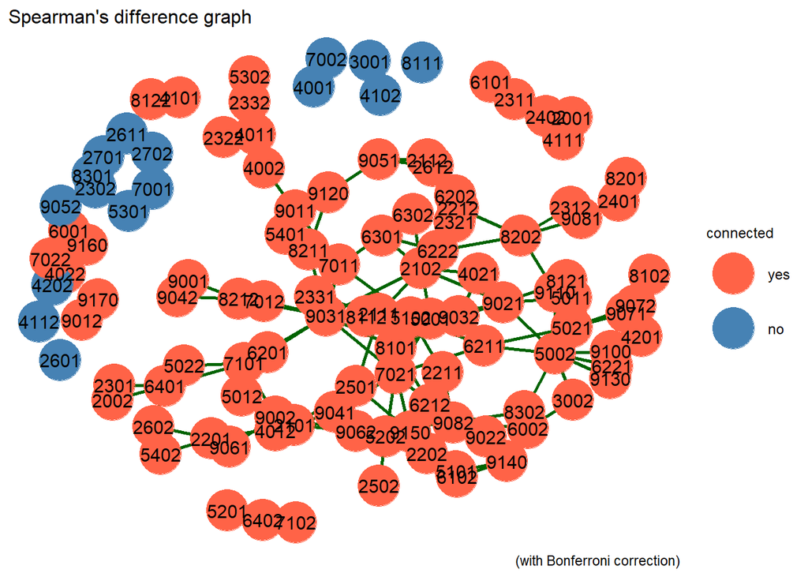

```r
th <- 0.45
CIlow2 <- delta_s_mtest$lowCI.bca
CIup2 <- delta_s_mtest$uppCI.bca
dimnames(CIlow2)<- dimnames(cor.s.asd)
dimnames(CIup2)<- dimnames(cor.s.asd)

delta.s.adj.mat <- matrix(0, nrow = n, ncol = n, dimnames = dimnames(cor.s.asd))
delta.s.adj.mat[(CIlow2 > th | CIup2 < - th)] <- 1

net <- network(x = delta.s.adj.mat, directed = FALSE, matrix.type = "adjacency")
net  %v% "connected" = ifelse(dimnames(asd.cor.mat)[[1]] %in% verteces.name, "yes", "no")
net %v% "color" = ifelse(net %v% "connected" == "yes", "tomato", "steelblue")
ggnet2(net, color = "connected",
       palette = c("yes" = "tomato", "no" = "steelblue"),
       mode = "fruchtermanreingold",
       layout.par = list(cell.jitter = 0.75),
        label = TRUE, label.size = 4,
       size = 12,
       edge.size = 1,
       edge.color = "darkgreen"
       ) +
  theme(
    plot.title = element_text(size=12)
  ) +
  labs(title = "Spearman's difference graph",
       caption = "(with Bonferroni correction)")
```

### The choice of the threshold

In order to choice a suitable threshold, we followed the following reasoning:

The null hypothesis is the proposition that there is no difference between the two populations. If the null hypothesis is true, any observed difference in populations would be due to sampling error (random chance). So, an experimental result was said to be statistically significant if a sample was sufficiently inconsistent with the (null) hypothesis, over the level of the noise. For this reason we determine a threshold that take into account the variability of the data, in order to determinate if observed test statistic is more extreme than would be expected, in symbol if $|\Delta r| > th$.

Our strategy is:

- obtain an estimate of the distribution of the *difference between the Spearman correlations*, via Bootstrap.
- obtain then an estimate of its standard error
- fix the threshold as two times the standard error

```r
boot_delta <- function(x1, x2, y1, y2, nboot = 599) {

  data1 <-matrix(sample(length(y1),size=length(y1)*nboot,replace=TRUE),nrow=nboot)
  bvec1 <- apply(data1, 1, function(xx) cor(rank(x1[xx]), rank(y1[xx])))

  data2<-matrix(sample(length(y2),size=length(y2)*nboot,replace=TRUE),nrow=nboot)
  bvec2<-apply(data2,1,function(xx) cor(rank(x2[xx]), rank(y2[xx])))

  brep <- bvec1-bvec2
  return(brep)
}

mat_g1 <- as.matrix(asd_mean)
mat_g2 <- as.matrix(td_mean)

n <- ncol(asd_mean)
brep <- c()
for (i in 1:(n - 1)) {
  for (j in (i + 1):n) {
    tmp <- boot_delta(x1 = mat_g1[, i], y1 = mat_g1[, j],
                      x2 = mat_g2[, i], y2 = mat_g2[, j])
    brep <- c(brep,tmp)
  }
}

round(summary(brep),3)
```

```
##    Min. 1st Qu.  Median    Mean 3rd Qu.    Max.
##  -1.053  -0.151   0.001   0.002   0.155   0.991
```

```r
se_boot <- sd(brep)
round(c(se_boot = se_boot),3)
```

```
## se_boot
##   0.225
```

Below the graph of the distribution estimate via bootstrap is shown; with the determination of standard error.

The threshold is fixed as: $th = 2 \times se$, where $se$ is the standar error.

[figure not shown]

```r
a <- 0.05
q <- 0 +  c(-1,1) * se_boot
q.abs <- 2*se_boot
hist(brep, probability = T, col = "tomato", border = "white",
     xlab = expression(hat(rho)[sASD] - hat(rho)[sTD]),
     main = "Bootstrap approximation to the sampling distribution \n of the difference between Spearman correlation",
     sub = "(points in yellow indicates the threshold)")
points(x = q[1],y = 0, bg = "yellow", pch = 21, col = "blue")
points(x = q[2],y = 0, bg = "yellow", pch = 21, col = "blue")
```

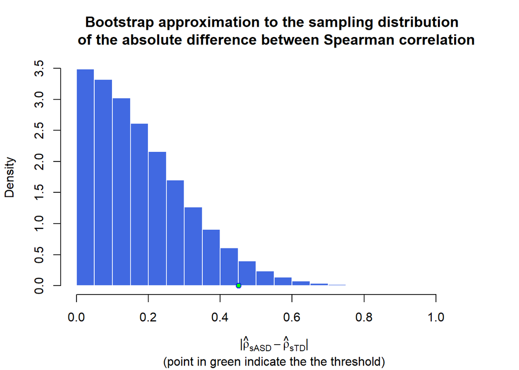

```r
hist(
  abs(brep), probability = T, col = "royalblue", border = "white",
     main = "Bootstrap approximation to the sampling distribution \n of the absolute difference between Spearman correlation",
  sub = "(point in green indicate the the threshold)",
  xlab =expression(paste("|", hat(rho)[sASD] - hat(rho)[sTD],"|"))
  )

points(x = q.abs, y = 0, bg = "green", pch = 21, col = "blue")
```

```r
cat("bootstrap estimate of the standard error", round(se_boot,3))
```

```
## bootstrap estimate of the standard error 0.225
```

```r
cat("\n")
```

```r
cat("\n")
```

```r
cat("Threshold fixed at: ", 2 * round(se_boot,3))
```

```
## Threshold fixed at:  0.45
```

### Spearman’s rank: Conclusion

```r
th <- 0.45

#check which ROI's confidence interval does not intersect [-t, t]
CIlow <- delta_s_mtest$lowCI.perc
CIup <- delta_s_mtest$uppCI.perc

CIlow[lower.tri(CIlow, diag = T)] <- 0
indeces <- which((CIlow > th | CIup < - th), arr.ind=TRUE)
cat("Number of edges:")
```

```
## Number of edges:
```

```r
cat("\n")
```

```r
nrow(indeces)
```

```
## [1] 174
```

However,it is reasonable to think that it is too small a number compared to the number of possible bonds (6670), and therefore we do not have sufficient evidence in favor of a difference between the two populations.

## Pool together the data: KMeans

We repeat now the experiment using a second way to pool together the data. In this chunk of code we try to create a 145x116 matrix for both the lists. In these matrices we want to concentrate all the information of the observation from the original datasets. So we apply the mean over them.Before doing it we want to distinguish in some way the samples that we want to use for the mean. For this reason we use the Kmeans algorithm to group the samples into 145 clusters that is the number of rows that we want to obtain in the final matrix. So the mean of each cluster corresponds to a row in the final matrix. The purpose of this is trying to take the mean of samples that are as close as possible to each other. In this way we try to keep all the information from the original dataset even in a shorter one. Before doing the Kmeans we normalize the sample values.

```r
# ASD ---------------------------------------------------------------
asd.mat= as.matrix(do.call(rbind,asd_sel))  #concatenate lists in asd_sel
rownames(asd.mat)=NULL #remove row names
asd.scaled=scale(asd.mat) # scale the range of the values

#KMeans
clusters <- kmeans(asd.scaled, 145)
asd.new= cbind(clusters$cluster,asd.scaled) # add the cluster column to the matrix

asd.final= matrix(NA,nrow = 145,ncol = 116) # result matrix
# for each cluster we take the mean of the columns, creating a new sample that contains the info
# about the most similar samples
for (i in 1:145){
  idx=which(asd.new[,1]==i)

  row= colMeans(as.matrix(asd.new[idx,2:117]))

  asd.final[i,]= t(row)

}

# TD  ----------------------------------------------------------------

td.mat= as.matrix(do.call(rbind,td_sel))  #concatenate lists in td_sel

rownames(td.mat)=NULL #remove row names

td.scaled=scale(td.mat) # scale the range of the values

#KMeans
clusters <- kmeans(td.scaled, 145)
td.new= cbind(clusters$cluster,td.scaled) # add the cluster column to the matrix

td.final= matrix(NA,nrow = 145,ncol = 116) # result matrix
# for each cluster we take the mean of the columns, creating a new sample that contains the info
# about the most similar samples
for (i in 1:145){
  idx=which(td.new[,1]==i)

  row= colMeans(as.matrix(td.new[idx,2:117]))

  td.final[i,]= t(row)

}
```

Now we use the functions to perform the correlation test. We have to test if each column is correlated to all the other columns. In our case we have to use the threshold t that we found before to check the correlation between two areas. So we used our version of the R function *cor.test* explained previously, using the Pearson correlation. We also apply again the Fisher’s transform to perform the test. So we get the atanh both of the absolute value of the correlation and the threshold and then we apply the formula in the variable ‘test’. From the result we calculate the p-value and the 95% confidence interval.

Now we apply the test functions to the ASD matrix and we use the p-value to evaluate the correlation between the areas. We first use the Bonferroni Correction that obviously give us a more accurate result. In fact the number of edges of the first graph is lower than the second one, so we avoided a lot of ‘False edges’, that correspond to areas that are not actually correlated.

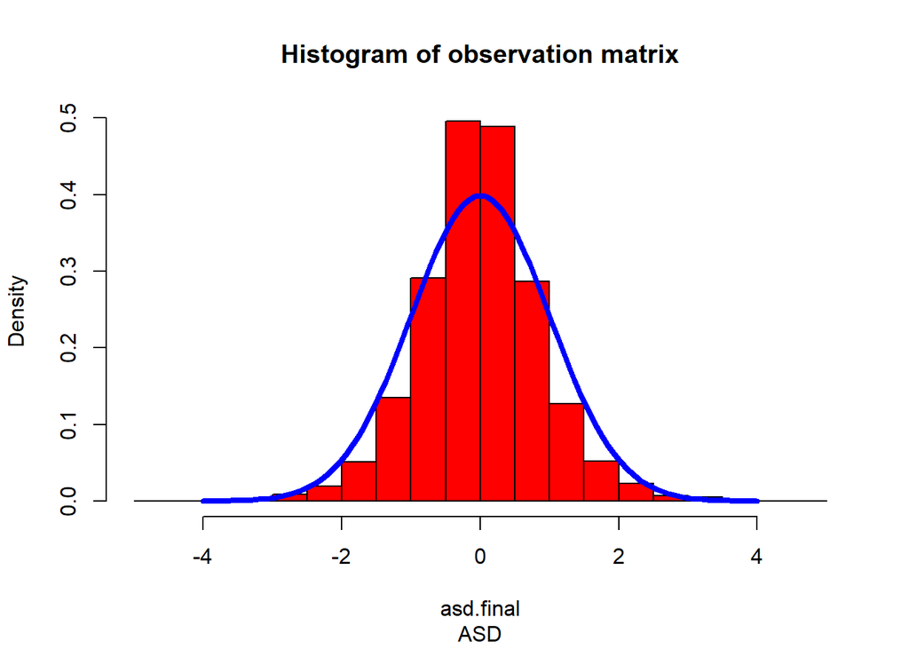

```r
#  ASD ----------------------------------------------------

#get the correlation matrix
asd.cor= cor(asd.final)
#plot asd matrix and add a normal distribution curve
hist(asd.final,col = 'Red',probability = T,main = 'Histogram of observation matrix',sub='ASD')
curve(dnorm(x,mean = 0,sd = 1),from = -4, to= 4,add=T,col= 'Blue',lwd= 4)
```

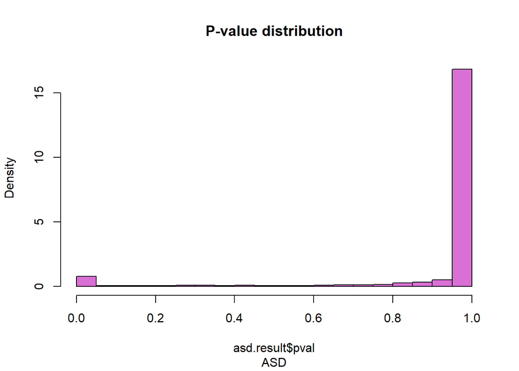

```r
asd.result= cor.mtest(asd.final,th)

hist(asd.result$pval,col='Orchid', probability = T,main= 'P-value distribution',sub='ASD')
```

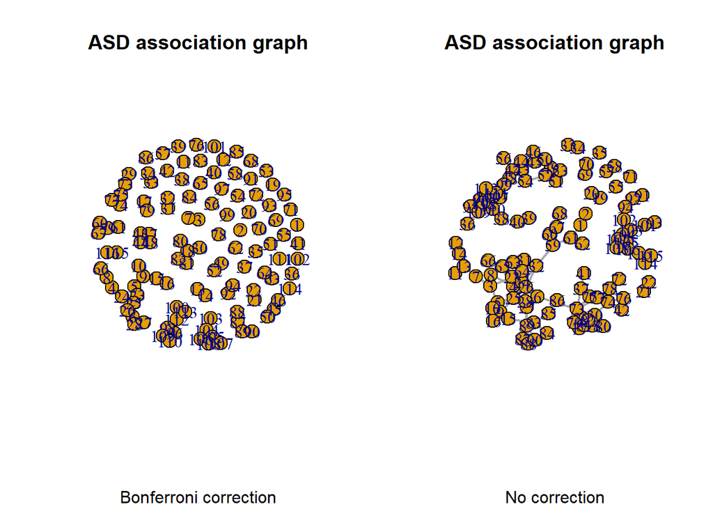

```r
alpha=0.05
m= choose(116,2)
p_val.mat  = matrix(0, nrow = nrow(asd.cor), ncol = ncol(asd.cor))

#Bonferroni correction
p_val.mat[which(asd.result$pval<(alpha/m))]=1
diag(p_val.mat)=0


G1 <- graph_from_adjacency_matrix(p_val.mat, mode = "undirected")


#without correction
p_val.mat.uncor=matrix(0, nrow = nrow(asd.cor), ncol = ncol(asd.cor))
p_val.mat.uncor[which(asd.result$pval<(alpha))]=1
diag(p_val.mat.uncor)=0

G1.uncorr <- graph_from_adjacency_matrix(p_val.mat.uncor, mode = "undirected")

par(mfrow= c(1,2))

plot(G1, main= 'ASD association graph',
     sub= 'Bonferroni correction',
     edge.width= 2,
     curved= T,
     vertex.size= 14)
plot(G1.uncorr, main= 'ASD association graph',
     sub= 'No correction',
     edge.width= 2,
     curved= T,
     vertex.size= 14)
```

We use the same method for the TD matrix, and we obtained the same results comparing the corrected graph with the uncorrected one.

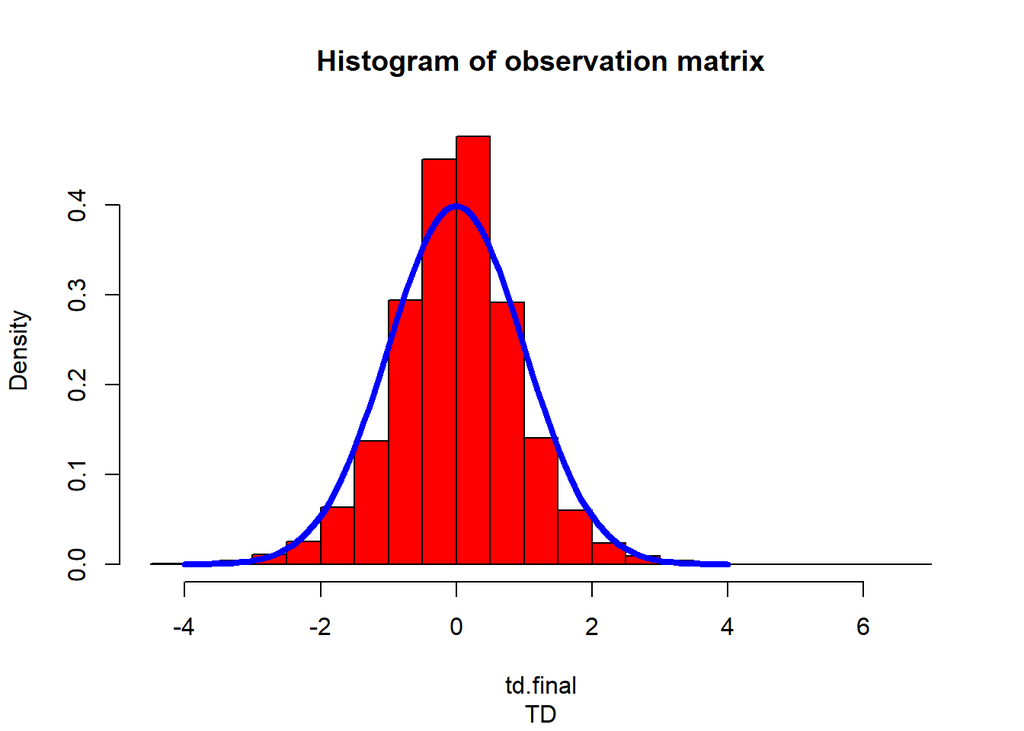

```r
#  TD -------------------------------------------------

td.cor= cor(td.final)
hist(td.final,col = 'Red',probability = T,main='Histogram of observation matrix',sub='TD')
curve(dnorm(x,mean = 0,sd = 1),from = -4, to= 4,add=T,col= 'Blue',lwd= 4)
```

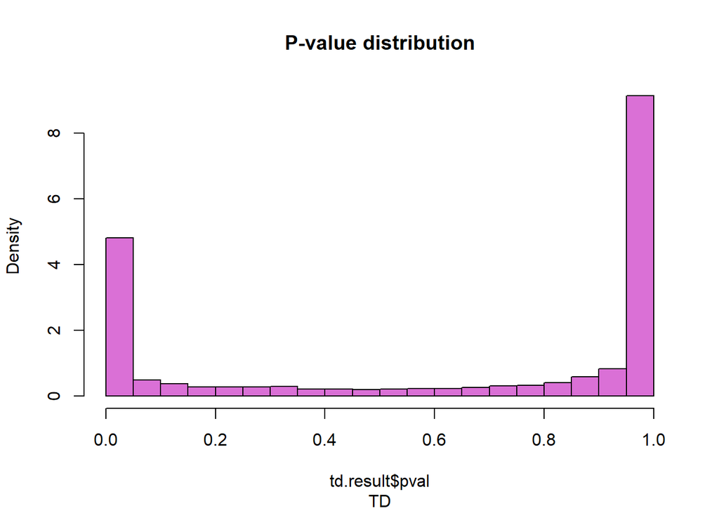

```r
td.result= cor.mtest(td.cor,th)

hist(td.result$pval,col='Orchid', probability = T,main = 'P-value distribution', sub='TD')
```

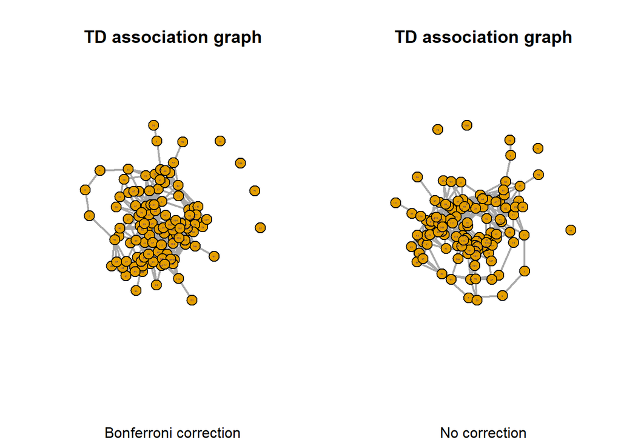

```r
alpha=0.05
m= choose(116,2)
p_val.mat.td  = matrix(0, nrow = nrow(td.cor), ncol = ncol(td.cor))

#Bonferroni correction
p_val.mat.td[which(td.result$pval<(alpha/m))]=1


View(p_val.mat.td)
diag(p_val.mat.td)=0


G2 <- graph_from_adjacency_matrix(p_val.mat.td, mode = "undirected")


#without correction
p_val.mat.td.uncorr  = matrix(0, nrow = nrow(td.cor), ncol = ncol(td.cor))

p_val.mat.td.uncorr[which(td.result$pval<(alpha))]=1
diag(p_val.mat.td.uncorr)=0

G2.uncorr <- graph_from_adjacency_matrix(p_val.mat.td, mode = "undirected")

par(mfrow= c(1,2))

plot(G2, main= 'TD association graph',
     sub= 'Bonferroni correction',
     edge.width= 2,
     curved= T,
     vertex.size= 12,
     vertex.label.cex=0.2)
plot(G2.uncorr, main= 'TD association graph',
     sub= 'No correction',
     edge.width= 2,
     curved= T,
     vertex.size= 12,
     vertex.label.cex=0.2)
```

```r
cat(c(sum(p_val.mat.td),sum(p_val.mat.td.uncorr)))
```

```
## 1328 3126
```

Now we are interested in the correlation differences between the two groups, so we want to test if the difference value of the correlations between all the columns is statistically significant. We define two new test functions. In the first we apply the test over all the pairs of columns, giving as argument two columns of the ASD matrix and the correspondents columns of TD matrix. Then we calculate two separate correlations and we check if the difference is significantly different from t, that is the same threshold we pick for the previous test. So we modify the test function as we did before, but now the quantity of interest ‘z’ is the difference between the absolute values of the correlations. We change also the value of sigma according to the correct formula.

Now we apply the function to the initial matrices and we use the Bonferroni correction to evaluate the result.

```r
diff.result=cor.mtest.diff(asd.final,td.final,th)
diag(diff.result$pval)=1
cat('The number of differences is: ',sum(diff.result$pval<(alpha/m)) )
```

```
## The number of differences is:  0
```

We can see that the correlation difference between the two groups is quite small.

```r
diff.result=cor.mtest.diff(asd.final,td.final,th)
diag(diff.result$pval)=1
cat('The number of differences is: ',sum(diff.result$pval<(alpha)) )
```

```
## The number of differences is:  8
```

### References

John Ruscio. 2008. “Constructing Confidence Intervals for Spearman’s Rank Correlation with Ordinal Data.”

Rand R. Wilcox. 2009. “Comparing Pearson Correlation Dealing with Heteroscedasticity and Non-Normality.”

———. n.d. “R/twopcor.R.”

Richard L. Gorsuch, Curtis S. Lehmann. 2010. “Correlation Coefficients Mean Bias and Confidence Interval Distortions.”

William Howard Beasley, Lise DeShea. 2007. “Bootstrapping to Test for Nonzero Population Correlation Coefficients Using Univariate Sampling.”